# Project Final: Chess

5/15/2020

# Bishop vs. Knight: Analyzing Chess Piece Powers

“Chess. Chess is a strategy game, and one of the oldest games in existence. Historians have determined that the first game of Chess was played sometime in the early 1980s, on the Nintendo Entertainment System. Back then, of course, it was called”Battle Chess," and it was so popular that in inspired a real life board game version of Battle Chess, called Chess." -Oscar Wilde

Chess is an excellent game, and one that has withstood the test of time and has been respected worldwide since the 80s.

From a computer’s perspective, the game poses a challenge. Technically, chess is a solvable game- that is, there does exist a perfectly optimal strategy, that (if known) would make gameplay wildly complicated and unbearably boring.

However, the optimal strategy for chess is so far outside of our grasp that we have to use other metrics to decide what good play looks like. Since chess is a popular game, there already exist a lot of robust algorithms to determine what is the closest line to optimal play. However, one of the first things you learn when you get into chess (to help find your footing) is the idea of piece point values.

There are 6 types of pieces in chess: Pawns, Rooks, Knights, Bishops, Kings, and Queens.

Each piece, when alive, can help you win the game. But how much does each piece being alive contribute?

Typically, the first thing you hear is: Pawns are worth one point, Knights/Bishops are worth 3, Rooks are worth 5, and Queens are worth 9. The King is worth the numerical equivalent of “Absolutely essential.”

These are pretty shaky heuristics, however, and they can vary depending on who you ask. A lot of people value knights much lower than bishops, and a few believe the value of the pawn decreases over time.

So, today we are going to look at some data, and see if we can come up with our own point-value system.

Part 1: The Data, and the Plan

The initial dataset can be found here: https://www.kaggle.com/milesh1/35-million-chess-games

It’s from the user “wanshan1” on Kaggle, and it has data on 3.5 million games played from the early 1800s until 2015.

It contains a lot of useful heuristics, such as ELO, or skill rating of the players.

The plan is to ask the following few questions to our dataset:

**Q:** When a player up <x piece(s)>, how likely are they to win the game?

**Q:** How does being up certain pieces correlate with winning the game?

**Q:** How do varying skill levels affect winning? Do better players tend to win by piece advantage, or through strategy invisible to the scope of this analysis?

**Q:** How consistent are these findings when looking at different sections of the game? (Ie, early game, mid game, late game)

This approach will be tricky, since the majority of these games are by skilled players, who are not making big mistakes every two seconds- furthermore, a lot of times “being up a piece” just means youre in the middle of a trade. Because of this, we will have to be clever in how we parse the data.

# Part 2: Parsing

The first main issue is that this dataset just lists the game as a series of moves- this makes it pretty difficult to do analysis (at least, using my R knowledge)

So, the first step is to suck all the useful data from the dataset that we can.

This chess data uses PGN (Portable Game Notation) to describe what happened in the game. This can be used to reconstruct the entire game, play by play.

So, I used a chess library in python to do that for me.

Then, I analyze each game and determine who has a piece advantage at each moment, and then record a running total. So, if white has been up two Pawns for 5 turns, then his pawn advantage would be recorded as +10. If black has been up 2 pawns for 5 turns, the pawn advantage is recorded as -10.

I record these values at the 10, 20, and 30 turn markers.

**NOTE: You can find the python script I wrote for this on my github, as explore.py!**

*Note: Now that all of our data is in place, it is worth mentioning the severe limitations of this approach. For one, I am intentionally ignoring things such as board positions. I am doing this to keep the scope manageable, and also because I have absolutely no prior knowledge about chess and how it is played*

# Part 3: EDA

Alright, we now have a juicy dataset from the first 50k games on the list.

Let’s start poking around and see what we can find:

```r
game <- "C:/Users/Ag/Desktop/Ag's Stuff/School/CMSC320/projF/gamebreakdown50k.txt"
gb <- read.csv(game)
gamestates <- "C:/Users/Ag/Desktop/Ag's Stuff/School/CMSC320/projF/boardstates50k.txt"
bs <- read.csv(gamestates)

gb %>% group_by(Winner) %>% count()
```

```
## # A tibble: 3 x 2
## # Groups:   Winner [3]
##   Winner     n
##   <fct>  <int>
## 1 B       6153
## 2 D      21199
## 3 W      22644
```

For some reason, there are 22000 white wins, 6000 black wins, and 20000 draws. So, the data is skewed- but lets see what else…

```r
gb %>% group_by(Winner) %>% summarize(m_p=mean(PawnAdv + KnightAdv + BishopAdv + RookAdv + QueenAdv))
```

```
## # A tibble: 3 x 2
##   Winner    m_p
##   <fct>   <dbl>
## 1 B      -21.1
## 2 D        1.27
## 3 W       15.3
```

```r
gb %>% group_by(Winner) %>% filter(PawnAdv30 < 500) %>% summarize(m_p=mean(PawnAdv30 + KnightAdv30 + BishopAdv30 + RookAdv30 + QueenAdv30))
```

```
## # A tibble: 3 x 2
##   Winner    m_p
##   <fct>   <dbl>
## 1 B      -0.808
## 2 D      -0.710
## 3 W      -0.531
```

```r
outcomes <- c("W","D","B")
bs <- bs %>% mutate(winnernum=(as.numeric(factor(Col1)) - 2))
wrs <- bs %>% group_by(Col6, Col7, Col8, Col9, Col10) %>% filter(winnernum != 0) %>% summarize(wr=mean(winnernum), counts=n()) %>% filter(counts > 50)
```

For games that end in a white victory, white has a running piece advantage of +15.3. For black victories, they tend to end the game at -21.1. For draws, white still has an average advantage of 1.27.

However, it seems that this effect is basically negligible in the midgame.

Furthermore, we also established a dataset called “wrs” to determine how likely it is that white wins from this position (scale of -1 to 1)

# Part 4: Hypothesis testing/machine learning/regression

Do these results hold up with our original 1-3-3-5-9 model? Let’s find out:

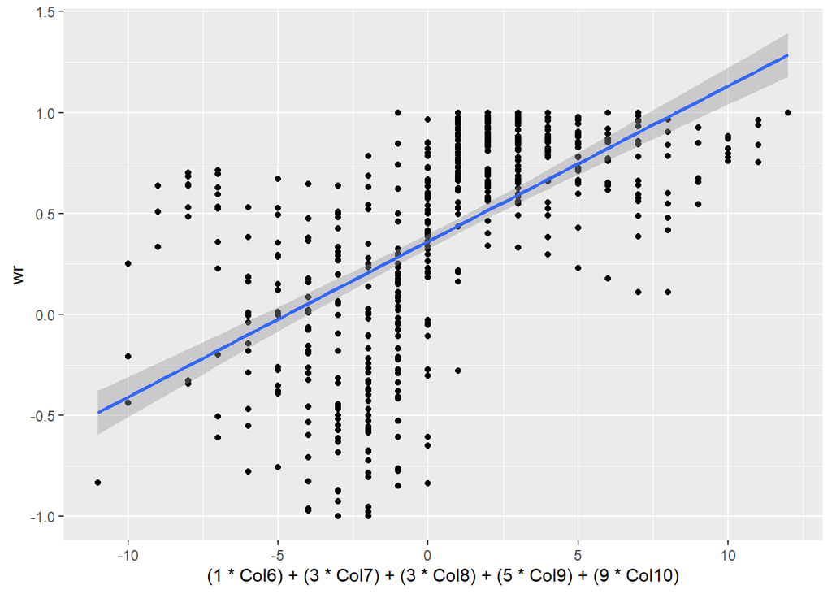

```r
wrs %>%
    ggplot(aes(x=(1 * Col6) + (3 * Col7) + (3 * Col8) + (5 * Col9) + (9 * Col10), y=wr)) + geom_point() + geom_smooth(method=lm)
```

This is a graph that looks at how likely white is to win from a given piece advantage. Ie, data points above 0 = white is more likely to win, below zero, black is more likely to win. The piece advantage is calculated based on the 1-3-3-5-9 conventional wisdom, and is displayed on the x axis- so, to the left is blacks advantage, to the right is whites advantage.

Things to note: Right away, im noticing very few values in the bottom right quadrant. this means that if white is winning, they usually win. However, white can still win when black is up pieces. This might be a data resolution issue.

The trick now is to minimize the regression, so-

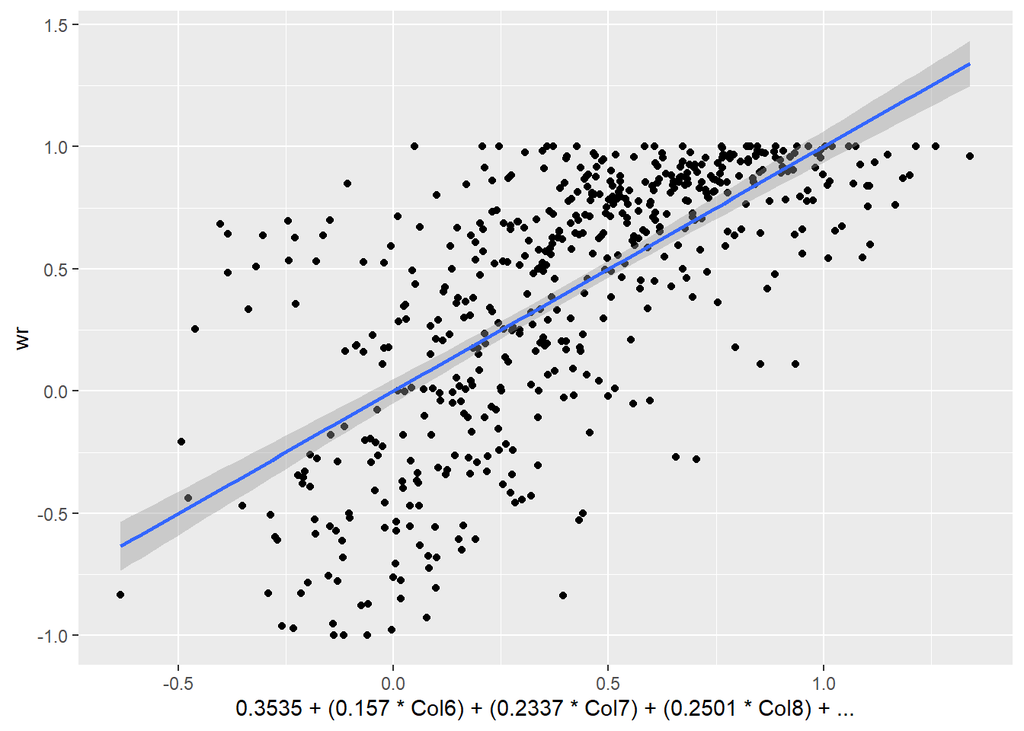

```r
lmint <- lm(wr~Col6+Col7+Col8+Col9+Col10, data=wrs)
wrs %>%
    ggplot(aes(x=.3535 + (.1570 * Col6) + (.2337 * Col7) + (.2501 * Col8) + (.3254 * Col9) + (.6734 * Col10), y=wr)) + geom_point() + geom_smooth(method=lm)
```

```r
lmint
```

```
##
## Call:
## lm(formula = wr ~ Col6 + Col7 + Col8 + Col9 + Col10, data = wrs)
##
## Coefficients:
## (Intercept)         Col6         Col7         Col8         Col9        Col10
##      0.3535       0.1570       0.2337       0.2501       0.3254       0.6734
```

My taking a linear regression on the winrates, we can find that the most suitable coefficients are actually the ones above.

# Part 5: Conclusion

By scaling the coefficients so that the pawn has a value of 1, we find that the “real” coefficients for winning are:

**PAWNS: 1** **KNIGHTS: 1.5** **BISHOPS: 1.6** **ROOKS: 2** **QUEEN: 4.3**

So, what’s different?

I think the key here is that pawns are more valuable than the 1-3-3-5-9 system would suggest. This makes sense, because in high level play, the game very often comes down to pawn advantage.

My favorite part of this outcome is it shows just how close knights are to bishops. People commonly say bishops are worth slightly more, but this “proves” that feeling.

The confusing part is the queen. Queens are more than twice as strong as rooks in this dataset. However, that sort of makes sense as well, since it would take 3 knights or 2 rooks to justify being down a queen. But even still, I didn’t realize it would be even more than 2x.